# One-Sample Means and Medians

## Introduction

- In the last module, we discussed describing data.
- In this module, we are discussing statistical inference on one sample.
  - Means / medians
  - Proportions
  - Variances / standard deviations
- In this lecture, we are focusing on one-sample means and medians.

## `R` Setup

```r
library(tidyverse)
library(ssstats)
```

- Recall our Zootopia data,

```r
zootopia <- read_csv("https://raw.githubusercontent.com/samanthaseals/SDSI/refs/heads/main/files/data/lectures/1-zootopia.csv")
```

| resident_name | department | district | academy_status | academy_exam_score | sleep_hours | hustle_earnings | district_temp_f |
| --- | --- | --- | --- | --- | --- | --- | --- |
| Sable Jones | Desk | Rainforest District | Fail | 65 | 5.5 | 14.72 | 72.2 |
| Kevin Frostwhisker | Patrol | Downtown | Fail | 69 | 7.4 | 45.66 | 66.2 |
| Jasper Duskrunner | Patrol | Sahara Square | Pass | 79 | 8.7 | 30.91 | 89.8 |

## Confidence Interval for $\mu$

- **(1–$\alpha$)100% CI for a population mean, $\mu$**

$$\bar{y} \pm t_{\alpha/2, n-1} \frac{s}{\sqrt{n}}$$

- where
  - $\bar{y}$ is the sample mean (the point estimate)
  - $t$ has $n-1$ degrees of freedom (the critical value)
  - $s$ is the sample standard deviation and $n$ is the sample size ($s/\sqrt{n}$ is the standard error of the mean)

## Hypothesis Test for $\mu$

- **Hypotheses**

**Two-Tailed**

$H_0: \mu = \mu_0$

$H_1: \mu \ne \mu_0$

**Left-Tailed**

$H_0: \mu \ge \mu_0$

$H_1: \mu < \mu_0$

**Right-Tailed**

$H_0: \mu \le \mu_0$

$H_1: \mu > \mu_0$

- $\mu$ is the population mean,
- $\mu_0$ is the hypothesized value of $\mu$.

## Hypothesis Test for $\mu$

- **Test Statistic**

$$t_0 = \frac{\bar{y} - \mu_0}{s/\sqrt{n}}$$

- where
  - $\bar{y}$ is the sample mean
  - $\mu_0$ is the hypothesized value of $\mu$
  - $s$ is the sample standard deviation
  - $n$ is the sample size

## Statistical Inference on One Mean (`R`)

- We will use the `one_mean()` function from `library(ssstats)` to perform statistical inference.

```r
dataset_name |> one_mean(outcome = variable_name,
                         mu = hypothesized_value,
                         alternative = "two" | "less" | "greater",
                         alpha = alpha_level)
```

**1**

Pipes `dataset_name` into `one_mean()`, and sets `outcome` to the variable being tested.

**2**

Sets `mu`, the hypothesized population value the sample mean is being compared against.

**3**

Sets `alternative`, the direction of the test: `"two"` for two-sided, `"less"` and `"greater"` for one-sided tests.

**4**

Sets `alpha`, the significance level.

- where
  - `outcome` is the variable name of the outcome variable
  - `mu` is the hypothesized value of the population mean
  - `alternative` is the alternative hypothesis (default = “two”)
  - `alpha` is the significance level (default = 0.05)

## Example 1

- The ZPD Academy claims that the passing exam average is 72 points. As Zootopia’s data analyst, you’ve been asked to check whether that claim actually holds up. We will use the `zootopia` dataset to answer the following question:
  - Is the true average exam score for this cohort actually 72, or has it shifted?
- First, we need to describe the data.
  - We start with point and interval estimates.
- Then, we will perform a hypothesis test to answer the question.

## Example 1

- Point and interval estimates:

```r
zootopia |> one_mean(outcome = academy_exam_score)
```

```
One-sample mean

x̅ = 77.3333 (SD = 8.023)

95% CI for μ: (74.3375, 80.3292)

Hypotheses:
H₀: μ = 0
H₁: μ ≠ 0
Test statistic: t(29) = 52.795
p-value: < 0.001
Conclusion: Reject the null hypothesis (p = < 0.001 < α = 0.050)
```

- The average exam score is 77.3 (95% CI: 74.3, 80.3).

## Example 1

- Then, we will perform a hypothesis test to answer the question.
  - Is the true average exam score for this cohort actually 72, or has it shifted?
- How do we translate this into hypotheses?
  - $H_0: \mu = 72$
  - $H_1: \mu \ne 72$
- For the `one_mean()` function, we will set
  - `mu = 72`
  - `alternative = "two"`.

## Example 1

- Is the true average exam score for this cohort actually 72, or has it shifted?

```r
zootopia |> one_mean(outcome = academy_exam_score,
                      mu = 72,
                      alternative = "two")
```

```
One-sample mean

x̅ = 77.3333 (SD = 8.023)

95% CI for μ: (74.3375, 80.3292)

Hypotheses:
H₀: μ = 72
H₁: μ ≠ 72
Test statistic: t(29) = 3.641
p-value: 0.001
Conclusion: Reject the null hypothesis (p = 0.001 < α = 0.050)
```

## Example 1

- **Hypotheses**
  - $H_0: \mu = 72$
  - $H_1: \mu \ne 72$
- **Test Statistic and *p*-Value**
  - $t_0 = 3.641$
  - $p = 0.001$
- **Rejection Region**
  - Reject $H_0$ if $p < \alpha$; $\alpha = 0.05$
- **Conclusion and Interpretation**
  - Reject $H_0$. There is sufficient evidence to suggest that the current average exam score is different from the assumed average of 72.

## Example 2

- Not everyone in Zootopia earns a paycheck the same way. Some residents have steady side hustles that bring in predictable income. The Zootopia City Council has claimed that the typical resident hustle income is Z 35. As the data analyst, you’ve been asked to check. We will use the `zootopia` dataset to answer the following question:
  - Is the typical side hustle income actually Z 35, or are residents earning more?
- First, we need to describe the data.
- Then, we will perform a hypothesis test to answer the question.

## Example 2

- Point and interval estimates:

```r
zootopia |> one_mean(outcome = hustle_earnings)
```

```
One-sample mean

x̅ = 36.7123 (SD = 22.7781)

95% CI for μ: (28.2068, 45.2178)

Hypotheses:
H₀: μ = 0
H₁: μ ≠ 0
Test statistic: t(29) = 8.828
p-value: < 0.001
Conclusion: Reject the null hypothesis (p = < 0.001 < α = 0.050)
```

- The average income is Z = 36.7 (95% CI: 28.2, 45.2).

## Example 2

- Then, we will perform a hypothesis test to answer the question.
  - Is the typical side hustle income actually Z 35, or are residents earning more?
- How do we translate this into hypotheses?
  - $H_0: \mu \le 35$
  - $H_1: \mu > 35$
- For the `one_mean()` function, we will set
  - `mu = 35`
  - `alternative = "greater"`.

## Example 2

- Is the typical side hustle income actually Z 35, or are residents earning more?

```r
zootopia |> one_mean(outcome = hustle_earnings,
                      mu = 35,
                      alternative = "greater")
```

```
One-sample mean

x̅ = 36.7123 (SD = 22.7781)

95% CI for μ: (28.2068, 45.2178)

Hypotheses:
H₀: μ ≤ 35
H₁: μ > 35
Test statistic: t(29) = 0.412
p-value: 0.342
Conclusion: Fail to reject the null hypothesis (p = 0.342 ≥ α = 0.050)
```

## Example 2

- **Hypotheses**
  - $H_0: \mu \le 35$
  - $H_1: \mu > 35$
- **Test Statistic and *p*-Value**
  - $t_0 = 0.412$
  - $p = 0.342$
- **Rejection Region**
  - Reject $H_0$ if $p < \alpha$; $\alpha = 0.05$
- **Conclusion and Interpretation**
  - Fail to reject $H_0$. There is not sufficient evidence to suggest that the current average income is greater than the assumed average of 35

## Assumption on One-Sample *t*

- We assume that the data has an approximate mound-shaped and symmetric distribution.
  - i.e., $y_1, y_2, \ldots, y_n \sim N(\mu, \sigma^2)$
- We will use a quantile-quantile plot (Q-Q plot) to check the assumption of normality.
  - We will also eyeball a histogram to further check the assumption of normality.

## Quantile-Quantile Plots

- A QQ plot (“quantile-quantile plot”) is a quick visual check for one question: does my data look *roughly* normal?
  - We do not need perfection – we just need “close enough.”

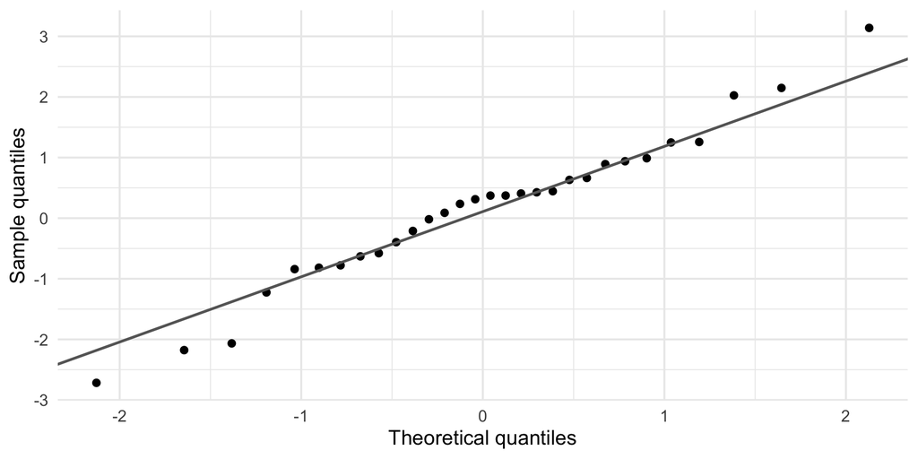

- Each dot compares one thing: where the observed data falls, versus where it *would* fall if your data were “perfectly normal.”
  - The diagonal line on the plot represents “perfectly normal.”

## Quantile-Quantile Plots

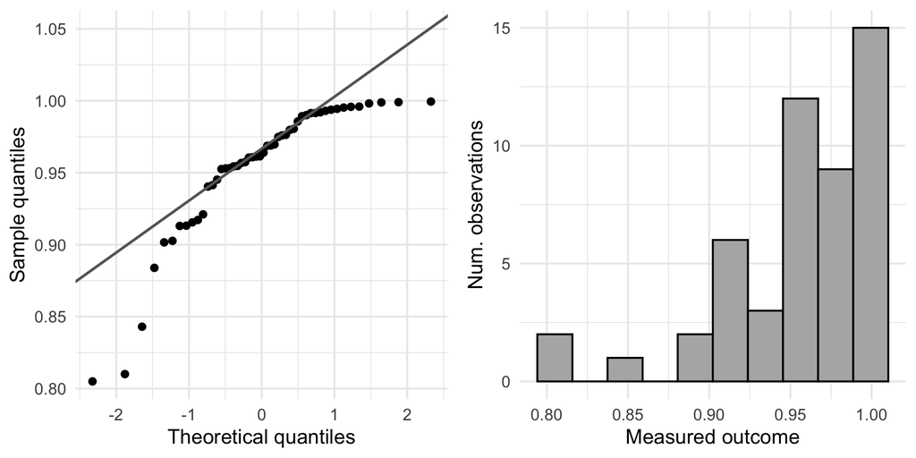

- Look at the left side of the plot: the dots dip below the line instead of following it.
  - This indicates *left-skewed* data.
- The histogram confirms that the data does not have a mound-shaped and symmetric distribution.

## Quantile-Quantile Plots

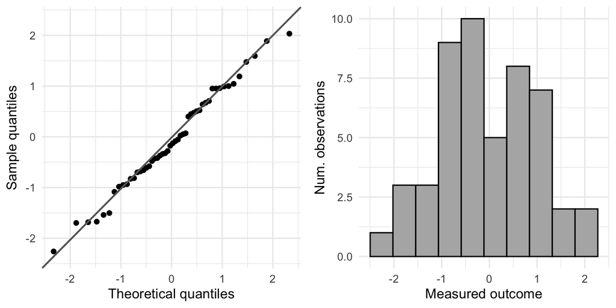

- Notice how closely the dots hug the diagonal line, especially through the middle.
  - A little wiggle at the very ends is normal, especially with small samples.
- The histogram confirms that the data has a mound-shaped and symmetric distribution.

## Quantile-Quantile Plots

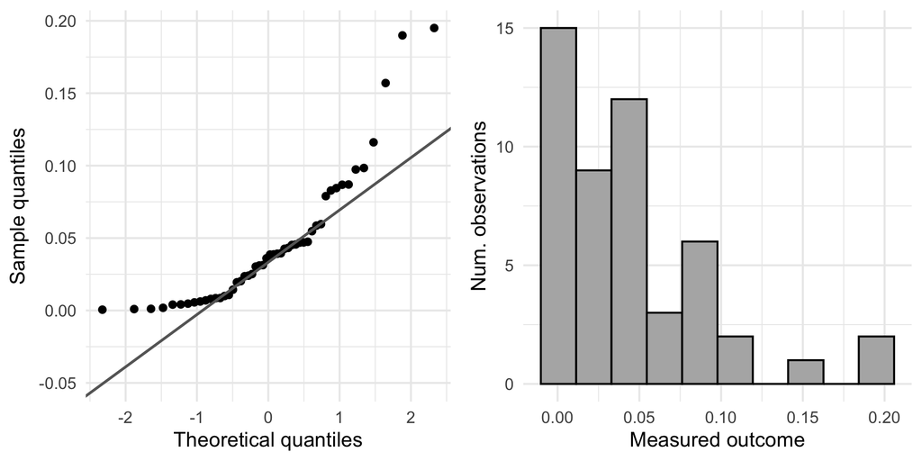

- Look at the right side of the plot: the dots rise above the line instead of following it.
  - This indicates *right-skewed* data.
- The historgram confirms that the data does not have a mound-shaped and symmetric distribution.

## Quantile-Quantile Plots

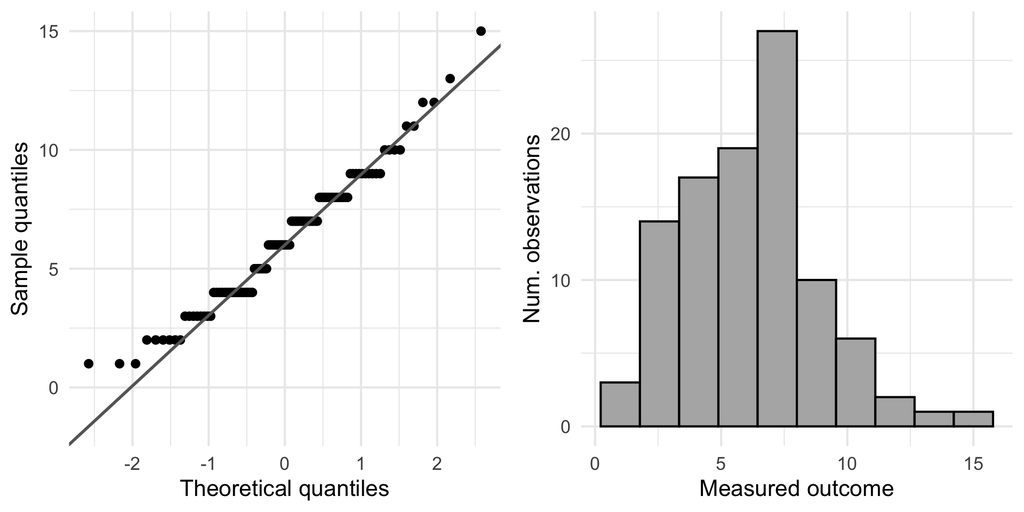

- Notice the dots aren’t a smooth curve, but instead are clustered like a staircase.
  - This happens because count (discrete) data can only take whole-number values (0, 1, 2, 3…). Many observations land on the exact same number, so the step represents the “density” of observations at that value.
- Again, the histogram confirms that the data does not have a mound-shaped and symmetric distribution.

## Checking Normality (`R`)

- We will use the `one_qq()` function from `library(ssstats)` to eyeball normality.

```r
dataset_name |> one_qq(outcome = variable_name)
```

**1**

Pipes `dataset_name` into `one_qq()`, generating a QQ plot for the `outcome` variable.

- where
  - `outcome` is the variable name of the outcome variable

## Example 1

- Let’s check the normality assumption for the `academy_exam_score` variable.

```r
zootopia |> one_qq(outcome = academy_exam_score)
```

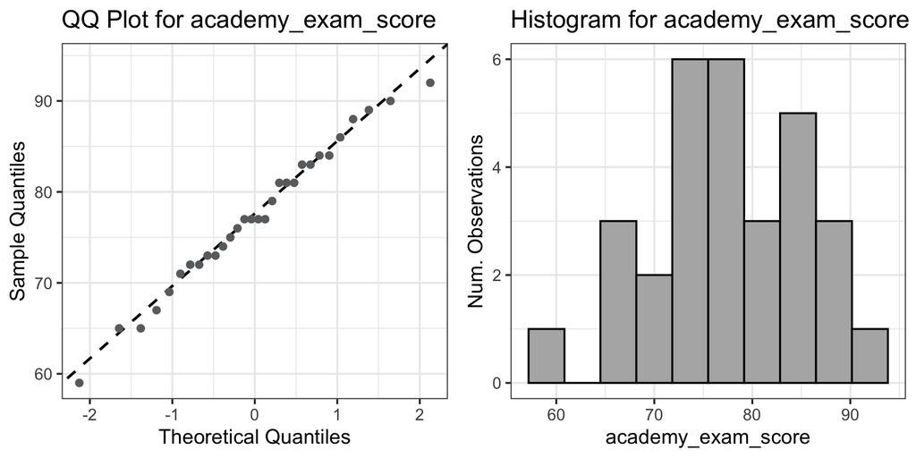

## Example 2

- Let’s check the normality assumption for the `hustle_earnings` variable.

```r
zootopia |> one_qq(outcome = hustle_earnings)
```

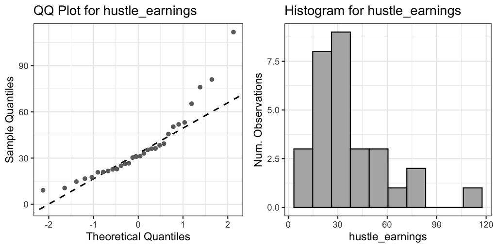

## Confidence Interval for $M$

- **(1–$\alpha$)100% CI for a population median, $M$**

$$(M_L, M_U) = (y_{(L_{\alpha/2})}, y_{(U_{\alpha/2})})$$

- where
  - $L_{\alpha/2}$ is the lower critical value of a binomial distribution with parameters $n$ and $p = 0.5$
  - $U_{\alpha/2}$ is the upper critical value of a binomial distribution with parameters $n$ and $p = 0.5$
- In R, linear interpolation is used to find the lower and upper bounds of the CI, making it a precise $(1-\alpha)100\%$ CI

## Hypothesis Test for $M$

- **Hypotheses**

**Two-Tailed**

$H_0: M = M_0$

$H_1: M \ne M_0$

**Left-Tailed**

$H_0: M \ge M_0$

$H_1: M < M_0$

**Right-Tailed**

$H_0: M \le M_0$

$H_1: M > M_0$

- where
  - $M$ is the population median,
  - $M_0$ is the hypothesized value of $M$.

## Hypothesis Test for $M$

- **Test Statistic**

$$S = \sum_{i=1}^n I_{(y_i > M_0)}$$

- where
  - $I$ is an indicator function that results in a 1 or a 0
    - The criteria is $y_i > M_0$ (1 if true, 0 if false); i.e., $S$ is the number of observations greater than the hypothesized median, $M_0$.
  - $n$ is the sample size

## Statistical Inference on One Median (`R`)

- We will use the `one_median()` function from `library(ssstats)` to perform statistical inference.

```r
dataset_name |> one_median(outcome = variable_name,
                            m = hypothesized_value,
                            alternative = "two" | "less" | "greater",
                            alpha = alpha_level)
```

**1**

Pipes `dataset_name` into `one_median()`, and sets `outcome` to the column being examined.

**2**

Sets `m`, the hypothesized population median the sample median is being compared against.

**3**

Sets `alternative`, the direction of the test: `"two"` for two-sided and `"less"` or `"greater"` for a one-sided test.

**4**

Sets `alpha`, the significance level.

- where
  - `outcome` is the variable name of the outcome variable
  - `m` is the hypothesized value of the population median
  - `alternative` is the alternative hypothesis (default = “two”)
  - `alpha` is the significance level (default = 0.05)

## Example 2

- Recall in the Zootopia data, we were investigating the typical income from side hustles. The research question was
  - Is the typical side hustle income actually Z 35, or are residents earning more?
- We saw that the normality was questionable, thus, we now want to apply a nonparametric approach.
- Our hypotheses now become
  - $H_0: M \le 35$
  - $H_1: M > 35$

## Example 2

- Is the typical side hustle income actually Z 35, or are residents earning more?
- Applying the `one_median()` function,

```r
zootopia |> one_median(outcome = hustle_earnings,
                        m = 35,
                        alternative = "greater")
```

```
One-sample median

Median = 31.07

95% CI for M: (23.1486, 37.9992)

Hypotheses:
H₀: M ≤ 35
H₁: M > 35
Test statistic: S = 13
p-value: 0.819
Conclusion: Fail to reject the null hypothesis (p = 0.819 ≥ α = 0.050)
```

## Example 2

- **Hypotheses**
  - $H_0: M \le 35$
  - $H_1: M > 35$
- **Test Statistic and *p*-Value**
  - $S = 13$ (13/30 were greater than 35)
  - $p = 0.819$
- **Rejection Region**
  - Reject $H_0$ if $p < \alpha$; $\alpha = 0.05$
- **Conclusion and Interpretation**
  - Fail to reject $H_0$. There is not sufficient evidence to suggest that the current median income is greater than the assumed median of 35

## Example 2

- Looking at the confidence interval,

```r
zootopia |> one_median(outcome = hustle_earnings,
                        m = 35,
                        alternative = "greater")
```

```
One-sample median

Median = 31.07

95% CI for M: (23.1486, 37.9992)

Hypotheses:
H₀: M ≤ 35
H₁: M > 35
Test statistic: S = 13
p-value: 0.819
Conclusion: Fail to reject the null hypothesis (p = 0.819 ≥ α = 0.050)
```

- We see that we are 95% confident that the true median income is between Z 23.14 and Z 37.99.

## Example 3

- The Zootopia Weather Bureau has publicly claimed that the average daily temperature across the city is 75°F. As the data analyst, you have a sample of daily temperature readings (*district_temp_f*).
  - Is the true average daily temperature actually 75°F, or does the data suggest otherwise?
- Our analysis steps:
  - QQ plot: should we describe the mean or median?
  - Point and interval estimation for mean/median
  - Hypothesis test for mean/median

## Example 3

- Checking the normality assumption for the `district_temp_f` variable.

```r
zootopia |> one_qq(outcome = district_temp_f)
```

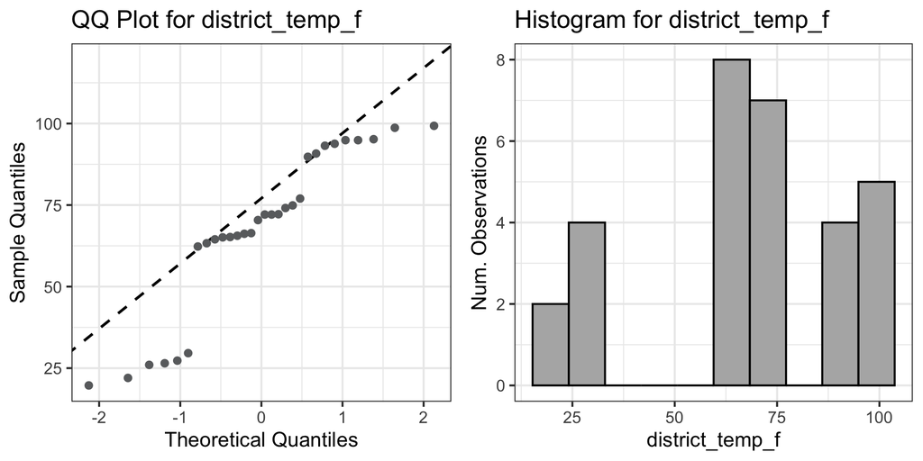

## Example 3

- Point and interval estimates:

```r
zootopia |> one_median(outcome = district_temp_f)
```

```
One-sample median

Median = 71.25

95% CI for M: (65.1129, 76.7288)

Hypotheses:
H₀: M = 0
H₁: M ≠ 0
Test statistic: S = 30
p-value: < 0.001
Conclusion: Reject the null hypothesis (p = < 0.001 < α = 0.050)
```

- The median temperature is 71.3°F (95% CI: 65.1, 76.7).

## Example 3

- Then, we will perform a hypothesis test to answer the question.
  - Is the true average daily temperature actually 75°F, or does the data suggest otherwise?
- How do we translate this into hypotheses?
  - $H_0: M = 75$
  - $H_1: M \ne 75$
- For the `one_median()` function, we will set
  - `m = 75`
  - `alternative = "two"`.

## Example 3

- Is the true average daily temperature actually 75°F, or does the data suggest otherwise?

```r
zootopia |> one_median(outcome = district_temp_f,
                        m = 75,
                        alternative = "two")
```

```
One-sample median

Median = 71.25

95% CI for M: (65.1129, 76.7288)

Hypotheses:
H₀: M = 75
H₁: M ≠ 75
Test statistic: S = 10
p-value: 0.099
Conclusion: Fail to reject the null hypothesis (p = 0.099 ≥ α = 0.050)
```

## Example 3

- **Hypotheses**
  - $H_0: M = 75$
  - $H_1: M \ne 75$
- **Test Statistic and *p*-Value**
  - $S = 10$
  - $p = 0.099$
- **Rejection Region**
  - Reject $H_0$ if $p < \alpha$; $\alpha = 0.05$
- **Conclusion and Interpretation**
  - Fail to reject $H_0$. There is not sufficient evidence to suggest that the current median daily temperature is different from the assumed median of 75°F.

## Wrap Up

- Using a $t$-test to examine the mean ($\mu$) requires normality.
  - We check normality with a quantile-quantile plot (`one_qq()`).
- The analysis you choose should match the needed method:
  - If we meet normality (`one_mean()`):
    - Point estimate: $\bar{y}$ to estimate $\mu$
    - Interval estimate: CI for $\mu$
    - One-sample $t$-test for $\mu$
  - If we do not meet normality (`one_median()`):
    - Point estimate: $m$(edian) to estimate $M$
    - Interval estimate: CI for $M$
    - One-sample sign test for $M$